# Deliverable 3

Jackson Geist

2026-10-30

```r
library(readxl)
library(tidyverse)
```

```r
library(ggplot2)
```

# Data Dictionary

```r
data_stats <- read_excel("C:/Users/Mashe/OneDrive - Florida Polytechnic University/Data anytics/data_stats.xlsx")
View(data_stats)
```

# Variables

Company = The overall company of the park (all disney), categorical

Incident_date = The specific calendar date on which the incident took place. Categorical

Ride_name = The specific name of the attraction or ride involved in the incident. Categorical

Theme_Park = The specific sub-park or theme park where the ride is located. Categorical

age = The age (in years) of the guest involved in the incident. Numerical (Discrete)

gender = The biological sex or gender marker of the guest. Categorical

description = Text details outlining the guest’s symptoms, injuries, or the nature of the incident. Categorical (Text)

# 2

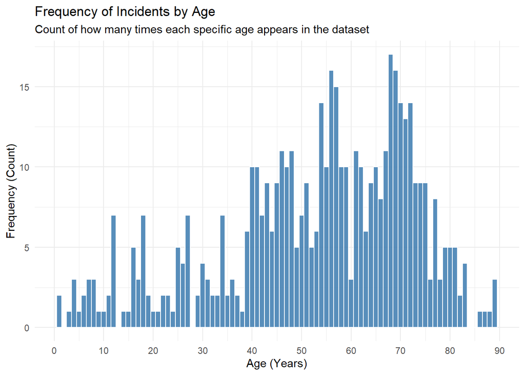

```r
## Graph 1
# Histogram of every age and their respective frequency of incidents from the year 2002-2022
ggplot(data_stats, aes(x = age)) +
  # bin width = 1 ensures every single age year gets its own individual bar
  geom_histogram(binwidth = 1, fill = "steelblue", color = "white", alpha = 0.9) +
  labs(
    title = "Frequency of Incidents by Age",
    subtitle = "Count of how many times each specific age appears in the dataset",
    x = "Age (Years)",
    y = "Frequency (Count)"
  ) +
  # tick marks on the X-axis every 10 years
  scale_x_continuous(breaks = seq(0, 100, by = 10)) +
  theme_minimal()
```

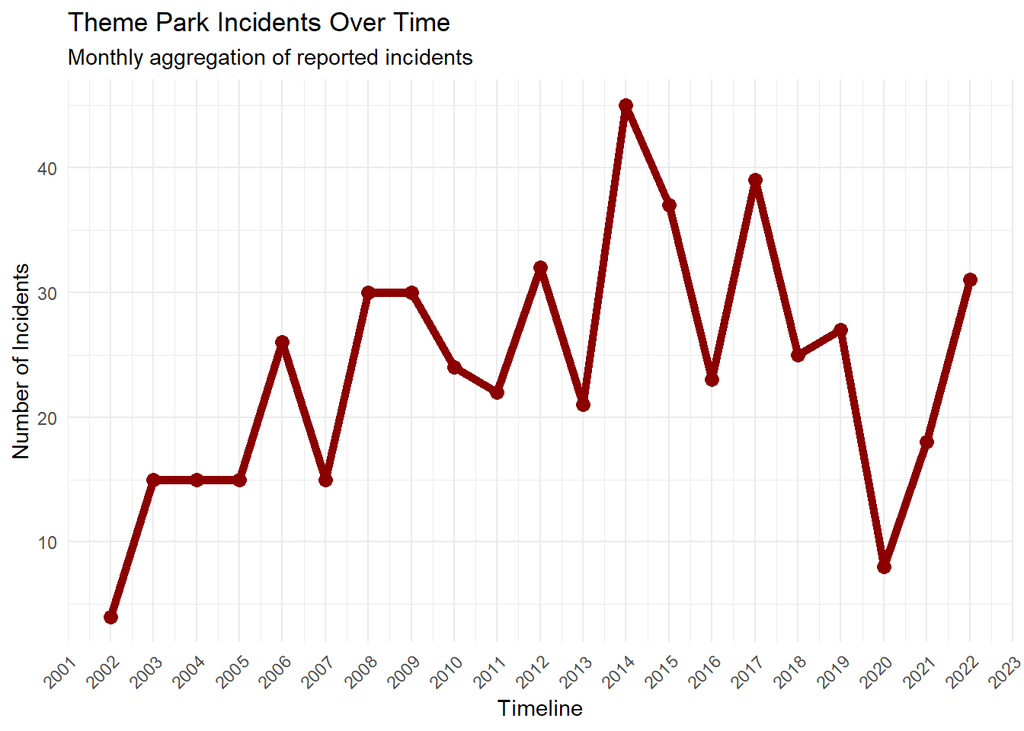

```r
# Graph 1's data is left skewed, meaning that the majority of incidents were among the older demographic of people. It is pretty stable throughout the children and then there starts to be a rise around 40 and peaks at 69-70.

#------------------------------------------------------------------------------------------------------

##Graph 2
# Line and point graph for the number of incidents for each year to see if there is a trend in history.
df_clean <- data_stats %>%
  mutate(Incident_date = as.Date(Incident_date))

# Group incidents by month for a clean trend line
df_timeline <- df_clean %>%
  mutate(Month_Year = floor_date(Incident_date, "year")) %>%
  count(Month_Year)

# Plot the timeline trend
ggplot(df_timeline, aes(x = Month_Year, y = n)) +
  geom_line(color = "darkred", linewidth = 2) +
  geom_point(color = "darkred", size = 3) +
  labs(
    title = "Theme Park Incidents Over Time",
    subtitle = "Monthly aggregation of reported incidents",
    x = "Timeline",
    y = "Number of Incidents"
  ) +
  # writes each year on the x axis
  scale_x_date(date_labels = "%Y", date_breaks = "1 year") +
  theme_minimal() +
  # writes the years at a 45 degree angle for better fit
  theme(axis.text.x = element_text(angle = 45, hjust = 1))
```

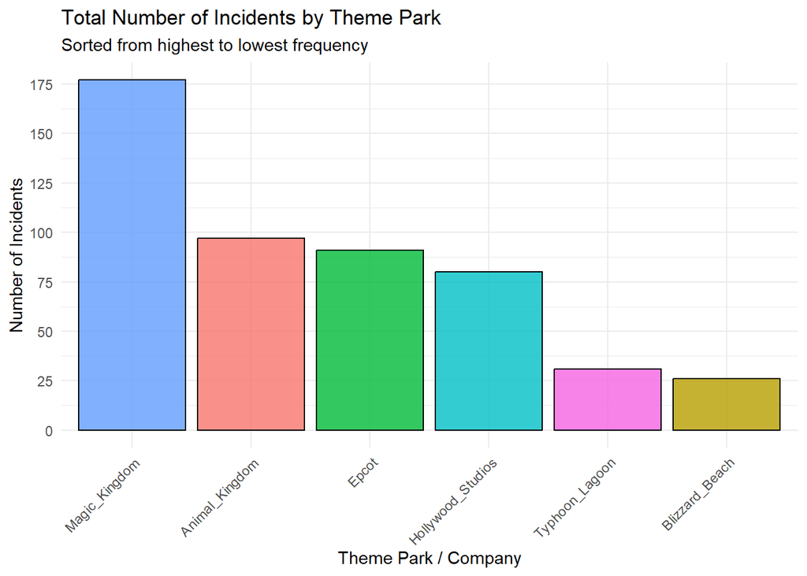

```r
#There are a few outliers in this graph the biggest being 2020, this is likely caused by the pandemic which forced Disney to close down for a period of time, meaning there were no guests to have incidents. But the lowest year was 2002 with less than 5 incidents which is unusual. Whereas the peak was in 2014 with 45 incidents. Overall the graph trends upwards until 2020 and then starts the positive trend again.

#--------------------------------------------------------------------------------------------------------

##Graph 3
# Bar graph for the number of incidents per park from 2002-2022
ggplot(data_stats, aes(x = fct_infreq(Theme_Park), fill = Theme_Park)) +
  geom_bar(color = "black", alpha = 0.8) +
  labs(
    title = "Total Number of Incidents by Theme Park",
    subtitle = "Sorted from highest to lowest frequency",
    x = "Theme Park / Company",
    y = "Number of Incidents"
  ) +
  scale_y_continuous(breaks = seq(0, 200, by = 25)) +
  theme_minimal() +
  # writes the X-axis labels to 45 degrees so long theme park names don't overlap
  theme(
    axis.text.x = element_text(angle = 45, hjust = 1),
    legend.position = "none" # Hides the legend since colors match the X-axis labels
  )
```

```r
#This graph shows how each park respectively had incidents in comparison to one another. Magic kingdom is by far the leader with roughly double than that of the next most, being Animal Kingdom. Magic Kingdom was a clear outline here, most likely because it has the most visitors out of all of the parks, so more people equals more people able to have an incident.
```